# Project 2C

Question: Are the hemagluttin from the two H3N2 strain in 2016 more similar to that of the 1968 H3N2 pandemic or the strain found in 2004?

Background: Influenza A viruses or IAV have been a major concern to the world as they have been the cause of 3 major pandemics in the past. These pandemics were the 1918 Spanish Influenza caused by H1N1, the 1957 Asian Influenza caused by H2N2, and the 1968 Hong Kong influenza caused by H3N2 (Hiroshi). Influenza A viruses are further subtyped based on two of their surface glycoproteins. These proteins are the hemagluttin or HA and neuraminidase or NA. The NA protein in IAV are responsible for cleaving sialic acid on the surface of the host cell, which allows for the viruses to leave the host cell and further spread to other cells. There are currently 11 known NA’s. The HA protein is important for the virus to be able to bind to sialic acid on the host cell, so it allows the virus into the cell. There are currently 18 known HA proteins. H3N2 is a subtype of influenza a that emerged in 1968 for the first time in humans in Hong Kong and was the cause of a global pandemic associated with more than one million deaths (Allen). From then on, H3N2 has been closely studied as it continues to circulate and evolve within the human population. However, a recent study found that from 2001 to 2010 there has been a pattern of declined avidity of human H3 viruses for avian receptors and also a significant decrease in H3’s affinity towards human for human receptors (Pu et al). The question is this pattern in H3N2 evolution still continuing even in more recent years.

Packages: BiocManager is useful for statistical analysis and comprehending highthoroughput genomic data. In my code specifically it was useful in running the multiple sequence alignment for my amino acid sequences.

msa: is a package within Biocmanager that provides the algorithm for running multiple sequence alignments

seqinr: is a package that is necessary for data analysis and visualization of biological sequences, like data and proteins. In the code this was specifically used to find the distance between each multiple sequence alignment.

ape is a package that allows for the reading, writing, plotting and manipulation of phylogenetic tree, so it was used to plot a phylogenetic tree of my amino acid sequences.

```r
#packages
library(BiocManager)
library(msa)
library(seqinr)
library(ape)
#read in amino acid sequence files, which were found on NCBI under the names
#have to read in fasta files as a string, instead of vector in order for the function msa to work
H3N2_1968_hongkong<- readAAStringSet("H3N2:1968.fasta")
H3N2_2004_sweden<-readAAStringSet("H3N2:2004.fasta")
H3N2_2016_tenessee<- readAAStringSet("H3N2:2016:tenessee.fasta")
H3N2_2016_florida<-readAAStringSet("H3N2:2016:florida.fasta")

#use multiple sequence alignment on 4 variables
all<-c(H3N2_2004_sweden, H3N2_1968_hongkong, H3N2_2016_florida, H3N2_2016_tenessee)
H3N2_alignment<-msa(all)
```

```
use default substitution matrix
```

```r
print(H3N2_alignment, show="complete")
```

```
MsaAAMultipleAlignment with 4 rows and 566 columns
    aln (1..88)                                                                              names
[1] MKTIIALSYILCLVFAQKIPGNDNSTATLCLGHHAVPNGTIVKTITNDRIEVTNATELVQNSSIGEICDSPHQVLDGENCTLIDALLG APO18550.1 hemagg...
[2] MKTIIALSYILCLVFAQKIPGNDNSTATLCLGHHAVPNGTIVKTITNDRIEVTNATELVQNSSIGEICDSPHQILDGENCTLIDALLG APO18562.1 hemagg...
[3] ----------------QKLPGNDNSTATLCLGHHAVPNGTIVKTITNDQIEVTNATELVQSSSTGGICDSPHQILDGENCTLIDALLG pdb|2YP5|A Chain ...
[4] MKTIIALSYIFCLALGQDLPGNDNSTATLCLGHHAVPNGTLVKTITDDQIEVTNATELVQSSSTGKICNNPHRILDGIDCTLIDALLG sp|Q91MA7.1|HEMA_...
Con MKTIIALSYILCLVFAQK?PGNDNSTATLCLGHHAVPNGTIVKTITND?IEVTNATELVQ?SS?GEICDSPHQILDGENCTLIDALLG Consensus

    aln (89..176)                                                                            names
[1] DPQCDGFQNKKWDLFVERSRAYSNCYPYDVPDYASLRSLVASSGTLEFKNESFNWTGVTQNGTSSACIRRSSSSFFSRLNWLTHLNYT APO18550.1 hemagg...
[2] DPQCDGFQNKKWDLFVERSKAYSNCYPYDVPDYASLRSLVASSGTLEFNNESFNWTGVTQNGTSSACIRRSSSSFFSRLNWLTHLNYT APO18562.1 hemagg...
[3] DPQCDGFQNKKWDLFVERSKAYSNCYPYDVPDYASLRSLVASSGTLEFNNESFNWTGVTQNGTSSACKRRSNNSFFSRLNWLTHLKFK pdb|2YP5|A Chain ...
[4] DPHCDVFQNETWDLFVERSKAFSNCYPYDVPDYASLRSLVASSGTLEFITEGFTWTGVTQNGGSNACKRGPGSGFFSRLNWLTKSGST sp|Q91MA7.1|HEMA_...
Con DPQCDGFQNKKWDLFVERSKAYSNCYPYDVPDYASLRSLVASSGTLEFNNESFNWTGVTQNGTSSAC?RRSSSSFFSRLNWLTHLNYT Consensus

    aln (177..264)                                                                           names
[1] YPALNVTMPNKEQFDKLYIWGVHHPGTDKDQIFLYARSSGRITVSTKRSQQAVIPNIGSRPRIRDIPSRISIYWTIVKPGDILLINST APO18550.1 hemagg...
[2] YPALNVTMPNKEQFDKLYIWGVHHPGTDKDQIFLYAQSSGRITVSTKRSQQAVIPNIGSRPRIRDIPSRISIYWTIVKPGDILLINST APO18562.1 hemagg...
[3] YPALNVTMPNNEKFDKLYIWGVHHPGTDNDQISLYAQASGRITVSTKRSQQTVIPNIGSRPRVRDIPSRISIYWTIVKPGDILLINST pdb|2YP5|A Chain ...
[4] YPVLNVTMPNNDNFDKLYIWGVHHPSTNQEQTSLYVQASGRVTVSTRRSQQTIIPNIGSRPWVRGLSSRISIYWTIVKPGDVLVINSN sp|Q91MA7.1|HEMA_...
Con YPALNVTMPN?EQFDKLYIWGVHHPGTDKDQI?LYAQ?SGRITVSTKRSQQ?VIPNIGSRPR?RDIPSRISIYWTIVKPGDILLINST Consensus

    aln (265..352)                                                                           names
[1] GNLIAPRGYFKIRSGKSSIMRSDAPIGKCKSECITPNGSIPNDKPFQNVNRITYGACPRYVKQSTLKLATGMRNVPEKQTRGIFGAIA APO18550.1 hemagg...
[2] GNLIAPRGYFKIRSGKSSIMRSDAPIGKCKSECITPNGSIPNDKPFQNVNRITYGACPRYVKHSTLKLATGMRNVPEKQTRGIFGAIA APO18562.1 hemagg...
[3] GNLIAPRGYFKIRSGKSSIMRSDAPIGKCNSECITPNGSIPNDKPFQNVNRITYGACPRYVKQNTLKLATGMRNVPEKQTQGIFGAIA pdb|2YP5|A Chain ...
[4] GNLIAPRGYFKMRTGKSSIMRSDAPIDTCISECITPNGSIPNDKPFQNVNKITYGACPKYVKQNTLKLATGMRNVPEKQTRGLFGAIA sp|Q91MA7.1|HEMA_...
Con GNLIAPRGYFKIRSGKSSIMRSDAPIGKCKSECITPNGSIPNDKPFQNVNRITYGACPRYVKQ?TLKLATGMRNVPEKQTRGIFGAIA Consensus

    aln (353..440)                                                                           names
[1] GFIENGWEGMVDGWYGFRHQNSEGRGQAADLKSTQAAIDQINGKLNRLIGKTNEKFHQIEKEFSEVEGRVQDLEKYVEDTKIDLWSYN APO18550.1 hemagg...
[2] GFIENGWEGMVDGWYGFRHQNSEGRGQAADLKSTQAAIDQINGKLNRLIGKTNEKFHQIEKEFSEVEGRVQDLEKYVEDTKIDLWSYN APO18562.1 hemagg...
[3] GFIENGWEGMVDGWYGFRHQNSEGIGQAADLKSTQAAINQINGKLNRLIGKTNEKFHQIEKEFSEVEGRIQDLEKYVEDTKIDLWSYN pdb|2YP5|A Chain ...
[4] GFIENGWEGMIDGWYGFRHQNSEGTGQAADLKSTQAAIDQINGKLNRVIEKTNEKFHQIEKEFSEVEGRIQDLEKYVEDTKIDLWSYN sp|Q91MA7.1|HEMA_...
Con GFIENGWEGMVDGWYGFRHQNSEGRGQAADLKSTQAAIDQINGKLNRLIGKTNEKFHQIEKEFSEVEGR?QDLEKYVEDTKIDLWSYN Consensus

    aln (441..528)                                                                           names
[1] AELLVALENQHTIDLTDSEMNKLFEKTKKQLRENAEDMGNGCFKIYHKCDNACIGSIRNETYDHNVYRDEALNNRFQIKGVELKSGYK APO18550.1 hemagg...
[2] AELLVALENQHTIDLTDSEMNKLFEKTKKQLRENAEDMGNGCFKIYHKCDNACIGSIRNETYDHNVYRDEALNNRFQIKGVELKSGYK APO18562.1 hemagg...
[3] AELLVALENQHTIDLTDSEMNKLFERTKKQLRENAEDMGNGCFKIYHKCDNACIGSIRNGTYDHDVYRDEALNNRFQIK--------- pdb|2YP5|A Chain ...
[4] AELLVALENQHTIDLTDSEMNKLFEKTRRQLRENAEDMGNGCFKIYHKCDNACIESIRNGTYDHDVYRDEALNNRFQIKGVELKSGYK sp|Q91MA7.1|HEMA_...
Con AELLVALENQHTIDLTDSEMNKLFEKTKKQLRENAEDMGNGCFKIYHKCDNACIGSIRN?TYDH?VYRDEALNNRFQIKGVELKSGYK Consensus

    aln (529..566)                         names
[1] DWILWISFAISCFLLCVVLLGFIMWACQKGNIRCNICI APO18550.1 hemagg...
[2] DWILWISFAISCFLLCVALLGFIMWACQKGNIRCNICI APO18562.1 hemagg...
[3] -------------------------------------- pdb|2YP5|A Chain ...
[4] DWILWISFAISCFLLCVVLLGFIMWACQRGNIRCNICI sp|Q91MA7.1|HEMA_...
Con DWILWISFAISCFLLCVVLLGFIMWACQKGNIRCNICI Consensus
```

```r
#convert to seqinr type alignment in order to calculate the distance between each sequence
H3N2_Al2<-msaConvert(H3N2_alignment, type="seqinr::alignment")

#calculate distance matrix
d<-dist.alignment(H3N2_Al2, "identity")
as.matrix(d)
```

```
                                                                                                                                                                       APO18550.1 hemagglutinin [Influenza A virus (A/Florida/88/2016(H3N2))]
APO18550.1 hemagglutinin [Influenza A virus (A/Florida/88/2016(H3N2))]                                                                                                                                                              0.0000000
APO18562.1 hemagglutinin [Influenza A virus (A/Tennessee/29/2016(H3N2))]                                                                                                                                                            0.1029597
pdb|2YP5|A Chain A, HEMAGGLUTININ                                                                                                                                                                                                   0.2482543
sp|Q91MA7.1|HEMA_I68A4 RecName: Full=Hemagglutinin; Contains: RecName: Full=Hemagglutinin HA1 chain; Contains: RecName: Full=Hemagglutinin HA2 chain; Flags: Precursor                                                              0.3852400
                                                                                                                                                                       APO18562.1 hemagglutinin [Influenza A virus (A/Tennessee/29/2016(H3N2))]
APO18550.1 hemagglutinin [Influenza A virus (A/Florida/88/2016(H3N2))]                                                                                                                                                                0.1029597
APO18562.1 hemagglutinin [Influenza A virus (A/Tennessee/29/2016(H3N2))]                                                                                                                                                              0.0000000
pdb|2YP5|A Chain A, HEMAGGLUTININ                                                                                                                                                                                                     0.2359364
sp|Q91MA7.1|HEMA_I68A4 RecName: Full=Hemagglutinin; Contains: RecName: Full=Hemagglutinin HA1 chain; Contains: RecName: Full=Hemagglutinin HA2 chain; Flags: Precursor                                                                0.3829401
                                                                                                                                                                       pdb|2YP5|A Chain A, HEMAGGLUTININ
APO18550.1 hemagglutinin [Influenza A virus (A/Florida/88/2016(H3N2))]                                                                                                                         0.2482543
APO18562.1 hemagglutinin [Influenza A virus (A/Tennessee/29/2016(H3N2))]                                                                                                                       0.2359364
pdb|2YP5|A Chain A, HEMAGGLUTININ                                                                                                                                                              0.0000000
sp|Q91MA7.1|HEMA_I68A4 RecName: Full=Hemagglutinin; Contains: RecName: Full=Hemagglutinin HA1 chain; Contains: RecName: Full=Hemagglutinin HA2 chain; Flags: Precursor                         0.3649668
                                                                                                                                                                       sp|Q91MA7.1|HEMA_I68A4 RecName: Full=Hemagglutinin; Contains: RecName: Full=Hemagglutinin HA1 chain; Contains: RecName: Full=Hemagglu…
APO18550.1 hemagglutinin [Influenza A virus (A/Florida/88/2016(H3N2))]                                                                                                                                                                                                                                      …
APO18562.1 hemagglutinin [Influenza A virus (A/Tennessee/29/2016(H3N2))]                                                                                                                                                                                                                                    …
pdb|2YP5|A Chain A, HEMAGGLUTININ                                                                                                                                                                                                                                                                           …
sp|Q91MA7.1|HEMA_I68A4 RecName: Full=Hemagglutinin; Contains: RecName: Full=Hemagglutinin HA1 chain; Contains: RecName: Full=Hemagglutinin HA2 chain; Flags: Precursor                                                                                                                                      …
```

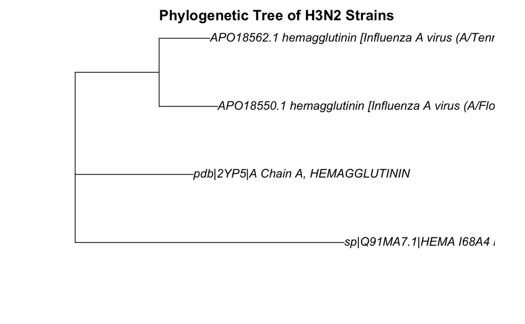

```r
#plot phylogenetic tree
H3N2_tree<-nj(d)
plot(H3N2_tree, main="Phylogenetic Tree of H3N2 Strains")
```

```r
#read in pdb files
H3N2_hongkong<-read_csv("1968.pdb")
```

[output not shown]